# RKM WEEK 13 IP Part 2

## 1.0 Defining the Question

Kira Plastinina is a Russian brand that is sold through a defunct chain of retail stores in Russia, Ukraine, Kazakhstan, Belarus, China, Philippines, and Armenia. The brand’s Sales and Marketing team would like to understand their customer’s behavior from data that they have collected over the past year. More specifically, they would like to learn the characteristics of customer groups.

### Data provided

Dataset Url = http://bit.ly/EcommerceCustomersDataset

### Data Glossary

‘Revenue’ attribute can be used as the class label

“Administrative”, “Administrative Duration”, “Informational”, “Informational Duration”, “Product Related” and “Product Related Duration” represents the number of different types of pages visited by the visitor in that session and total time spent in each of these page categories. The values of these features are derived from the URL information of the pages visited by the user and updated in real-time when a user takes an action, e.g. moving from one page to another.

“Bounce Rate”, “Exit Rate” and “Page Value” features represent the metrics measured by “Google Analytics” for each page in the e-commerce site.

“Bounce Rate” feature for a web page refers to the percentage of visitors who enter the site from that page and then leave (“bounce”) without triggering any other requests to the analytics server during that session.

“Exit Rate” feature for a specific web page is calculated as for all pageviews to the page, the percentage that was the last in the session.

“Page Value” feature represents the average value for a web page that a user visited before completing an e-commerce transaction.

“Special Day” feature indicates the closeness of the site visiting time to a specific special day (e.g. Mother’s Day, Valentine’s Day) in which the sessions are more likely to be finalized with the transaction. The value of this attribute is determined by considering the dynamics of e-commerce such as the duration between the order date and delivery date. For example, for Valentine’s day, this value takes a nonzero value between February 2 and February 12, zero before and after this date unless it is close to another special day, and its maximum value of 1 on February 8.

The dataset also includes the operating system, browser, region, traffic type, visitor type as returning or new visitor, a Boolean value indicating whether the date of the visit is weekend, and month of the year.

## 1.1 Specifying the data analytic

Use clustering (K-Means and Hierarchical) to group customers according to their behavior.

## 1.2 Defining the metric for success

Identify individuals that are likely to click on the add after performing exploratory data analysis

## 1.4 Recording the Experimental

1.Data Loading

2.Data cleaning for missing values and outliers

3.Exploratory Data Analysis

4. Perform clustering stating insights drawn from your analysis and visualizations.
5. Upon implementation, provide comparisons between the approaches learned this week i.e. K-Means clustering vs Hierarchical clustering highlighting the strengths and limitations of each approach in the context of your analysis

6.Conclusion-Detecting the trend in behavior.

## 1.5 Assessing the Relevance of the Data

The dataset provided has ecommerce data and it is genuine.

## 2.0 Importing package

```r
## 2.0 Importing packages
#
#importing libraries
#
#install.packages("caret")
#loading the library
library(data.table) # load package
#install.packages(c("Rcpp","tidyverse")) # install packages to work with data frame - extends into visualization
library(tidyverse)
library("caret")
```

##2.1 Importing dataset

```r
# Dataset Url = http://bit.ly/EcommerceCustomersDataset
# Importing our dataset
# ---
#
customer_data <- read.csv('http://bit.ly/EcommerceCustomersDataset')

# Previewing the dataset
# ---
#having a look at the dataset
head(customer_data,6)
```

```
##   Administrative Administrative_Duration Informational Informational_Duration
## 1              0                       0             0                      0
## 2              0                       0             0                      0
## 3              0                      -1             0                     -1
## 4              0                       0             0                      0
## 5              0                       0             0                      0
## 6              0                       0             0                      0
##   ProductRelated ProductRelated_Duration BounceRates ExitRates PageValues
## 1              1                0.000000  0.20000000 0.2000000          0
## 2              2               64.000000  0.00000000 0.1000000          0
## 3              1               -1.000000  0.20000000 0.2000000          0
## 4              2                2.666667  0.05000000 0.1400000          0
## 5             10              627.500000  0.02000000 0.0500000          0
## 6             19              154.216667  0.01578947 0.0245614          0
##   SpecialDay Month OperatingSystems Browser Region TrafficType
## 1          0   Feb                1       1      1           1
## 2          0   Feb                2       2      1           2
## 3          0   Feb                4       1      9           3
## 4          0   Feb                3       2      2           4
## 5          0   Feb                3       3      1           4
## 6          0   Feb                2       2      1           3
##         VisitorType Weekend Revenue
## 1 Returning_Visitor   FALSE   FALSE
## 2 Returning_Visitor   FALSE   FALSE
## 3 Returning_Visitor   FALSE   FALSE
## 4 Returning_Visitor   FALSE   FALSE
## 5 Returning_Visitor    TRUE   FALSE
## 6 Returning_Visitor   FALSE   FALSE
```

### Previewing the dataset

```r
#viewing the dataset

View(customer_data)
```

observation: 12,330 records and 18 total columns.

### checking the colunms summary

```r
# checking the content/summary statistics of each column.
str(customer_data)
```

```
## 'data.frame':    12330 obs. of  18 variables:
##  $ Administrative         : int  0 0 0 0 0 0 0 1 0 0 ...
##  $ Administrative_Duration: num  0 0 -1 0 0 0 -1 -1 0 0 ...
##  $ Informational          : int  0 0 0 0 0 0 0 0 0 0 ...
##  $ Informational_Duration : num  0 0 -1 0 0 0 -1 -1 0 0 ...
##  $ ProductRelated         : int  1 2 1 2 10 19 1 1 2 3 ...
##  $ ProductRelated_Duration: num  0 64 -1 2.67 627.5 ...
##  $ BounceRates            : num  0.2 0 0.2 0.05 0.02 ...
##  $ ExitRates              : num  0.2 0.1 0.2 0.14 0.05 ...
##  $ PageValues             : num  0 0 0 0 0 0 0 0 0 0 ...
##  $ SpecialDay             : num  0 0 0 0 0 0 0.4 0 0.8 0.4 ...
##  $ Month                  : chr  "Feb" "Feb" "Feb" "Feb" ...
##  $ OperatingSystems       : int  1 2 4 3 3 2 2 1 2 2 ...
##  $ Browser                : int  1 2 1 2 3 2 4 2 2 4 ...
##  $ Region                 : int  1 1 9 2 1 1 3 1 2 1 ...
##  $ TrafficType            : int  1 2 3 4 4 3 3 5 3 2 ...
##  $ VisitorType            : chr  "Returning_Visitor" "Returning_Visitor" "Returning_Visitor" "Returning_Visitor" ...
##  $ Weekend                : logi  FALSE FALSE FALSE FALSE TRUE FALSE ...
##  $ Revenue                : logi  FALSE FALSE FALSE FALSE FALSE FALSE ...
```

observation: the dataset comprise of integer, numerical, categorical and logical datatypes.

### displaying dataset dimension

```r
# checking the dataset dimension(displaying the number of rows and columns).
dim(customer_data)
```

```
## [1] 12330    18
```

```r
# checking dataset class
class(customer_data)
```

```
## [1] "data.frame"
```

# converting the data into a tibble for easy manupulation

```r
#For ease in analysis we convert the data into a tibble
cs_data<-as_tibble(customer_data)
cs_data
```

```
## # A tibble: 12,330 x 18
##    Administrative Administrative_~ Informational Informational_D~ ProductRelated
##             <int>            <dbl>         <int>            <dbl>          <int>
##  1              0                0             0                0              1
##  2              0                0             0                0              2
##  3              0               -1             0               -1              1
##  4              0                0             0                0              2
##  5              0                0             0                0             10
##  6              0                0             0                0             19
##  7              0               -1             0               -1              1
##  8              1               -1             0               -1              1
##  9              0                0             0                0              2
## 10              0                0             0                0              3
## # ... with 12,320 more rows, and 13 more variables:
## #   ProductRelated_Duration <dbl>, BounceRates <dbl>, ExitRates <dbl>,
## #   PageValues <dbl>, SpecialDay <dbl>, Month <chr>, OperatingSystems <int>,
## #   Browser <int>, Region <int>, TrafficType <int>, VisitorType <chr>,
## #   Weekend <lgl>, Revenue <lgl>
```

#checking dataset summary

```r
# dataset summary
summary(cs_data)
```

```
##  Administrative   Administrative_Duration Informational
##  Min.   : 0.000   Min.   :  -1.00         Min.   : 0.000
##  1st Qu.: 0.000   1st Qu.:   0.00         1st Qu.: 0.000
##  Median : 1.000   Median :   8.00         Median : 0.000
##  Mean   : 2.318   Mean   :  80.91         Mean   : 0.504
##  3rd Qu.: 4.000   3rd Qu.:  93.50         3rd Qu.: 0.000
##  Max.   :27.000   Max.   :3398.75         Max.   :24.000
##  NA's   :14       NA's   :14              NA's   :14
##  Informational_Duration ProductRelated   ProductRelated_Duration
##  Min.   :  -1.00        Min.   :  0.00   Min.   :   -1.0
##  1st Qu.:   0.00        1st Qu.:  7.00   1st Qu.:  185.0
##  Median :   0.00        Median : 18.00   Median :  599.8
##  Mean   :  34.51        Mean   : 31.76   Mean   : 1196.0
##  3rd Qu.:   0.00        3rd Qu.: 38.00   3rd Qu.: 1466.5
##  Max.   :2549.38        Max.   :705.00   Max.   :63973.5
##  NA's   :14             NA's   :14       NA's   :14
##   BounceRates         ExitRates         PageValues        SpecialDay
##  Min.   :0.000000   Min.   :0.00000   Min.   :  0.000   Min.   :0.00000
##  1st Qu.:0.000000   1st Qu.:0.01429   1st Qu.:  0.000   1st Qu.:0.00000
##  Median :0.003119   Median :0.02512   Median :  0.000   Median :0.00000
##  Mean   :0.022152   Mean   :0.04300   Mean   :  5.889   Mean   :0.06143
##  3rd Qu.:0.016684   3rd Qu.:0.05000   3rd Qu.:  0.000   3rd Qu.:0.00000
##  Max.   :0.200000   Max.   :0.20000   Max.   :361.764   Max.   :1.00000
##  NA's   :14         NA's   :14
##     Month           OperatingSystems    Browser           Region
##  Length:12330       Min.   :1.000    Min.   : 1.000   Min.   :1.000
##  Class :character   1st Qu.:2.000    1st Qu.: 2.000   1st Qu.:1.000
##  Mode  :character   Median :2.000    Median : 2.000   Median :3.000
##                     Mean   :2.124    Mean   : 2.357   Mean   :3.147
##                     3rd Qu.:3.000    3rd Qu.: 2.000   3rd Qu.:4.000
##                     Max.   :8.000    Max.   :13.000   Max.   :9.000
##
##   TrafficType    VisitorType         Weekend         Revenue
##  Min.   : 1.00   Length:12330       Mode :logical   Mode :logical
##  1st Qu.: 2.00   Class :character   FALSE:9462      FALSE:10422
##  Median : 2.00   Mode  :character   TRUE :2868      TRUE :1908
##  Mean   : 4.07
##  3rd Qu.: 4.00
##  Max.   :20.00
##
```

## 3.0 Data cleaning

###3.0a missing values

```r
# Identify missing data in our entire dataset using is.na() function


colSums(is.na(cs_data))
```

```
##          Administrative Administrative_Duration           Informational
##                      14                      14                      14
##  Informational_Duration          ProductRelated ProductRelated_Duration
##                      14                      14                      14
##             BounceRates               ExitRates              PageValues
##                      14                      14                       0
##              SpecialDay                   Month        OperatingSystems
##                       0                       0                       0
##                 Browser                  Region             TrafficType
##                       0                       0                       0
##             VisitorType                 Weekend                 Revenue
##                       0                       0                       0
```

### dealing with missing values

```r
#dropping missing values
cs_data <- na.omit(cs_data)
#
#comfirming no more missing values
colSums(is.na(cs_data))
```

```
##          Administrative Administrative_Duration           Informational
##                       0                       0                       0
##  Informational_Duration          ProductRelated ProductRelated_Duration
##                       0                       0                       0
##             BounceRates               ExitRates              PageValues
##                       0                       0                       0
##              SpecialDay                   Month        OperatingSystems
##                       0                       0                       0
##                 Browser                  Region             TrafficType
##                       0                       0                       0
##             VisitorType                 Weekend                 Revenue
##                       0                       0                       0
```

observations: all missing values were dropped.

```r
#checking our dataset dimension after dropping missing values
dim(cs_data)
```

```
## [1] 12316    18
```

observation: we have not lost too many records

### 3.1a Duplicated Data

```r
#Identifying Duplicated Data
#
duplicate_rows <- cs_data[duplicated(cs_data),]
duplicate_rows
```

```
## # A tibble: 117 x 18
##    Administrative Administrative_~ Informational Informational_D~ ProductRelated
##             <int>            <dbl>         <int>            <dbl>          <int>
##  1              0                0             0                0              1
##  2              0                0             0                0              1
##  3              0                0             0                0              1
##  4              0                0             0                0              1
##  5              0                0             0                0              1
##  6              0                0             0                0              1
##  7              0                0             0                0              1
##  8              0                0             0                0              1
##  9              0                0             0                0              2
## 10              0                0             0                0              1
## # ... with 107 more rows, and 13 more variables: ProductRelated_Duration <dbl>,
## #   BounceRates <dbl>, ExitRates <dbl>, PageValues <dbl>, SpecialDay <dbl>,
## #   Month <chr>, OperatingSystems <int>, Browser <int>, Region <int>,
## #   TrafficType <int>, VisitorType <chr>, Weekend <lgl>, Revenue <lgl>
```

observation: a couple of colunms has duplicated values. checking further for the sum of duplicates

```r
# checking for duplicated records
anyDuplicated(cs_data)
```

```
## [1] 159
```

###dealing with the duplicates

```r
# removing duplicates using unique () function
cs_data <- unique(cs_data)

#confirming no duplicates.
anyDuplicated(cs_data)
```

```
## [1] 0
```

###checking the new dimension

```r
#checking dataset dimension
dim(cs_data)
```

```
## [1] 12199    18
```

###3.2 Outliers

### installing outlier package and library

```r
# installing outlier package
#install.packages("outliers")
#
library(outliers)
```

## converting some columns to categorical datatypes.

‘month’, ‘The OperatingSystems’, ‘Browser’, ‘Region’, and ‘TrafficType variables’, vistor type’ are categorical in nature and not numerical, they have already been encoded to make them easier to work with. also ‘Weekend’ and ‘Revenue’ columns. We will convert all of them to their appropriate data type.

```r
#converting colunms to categorical datatypes
#
cs_data$Month  <- as.factor(cs_data$Month)
cs_data$OperatingSystems <- as.factor(cs_data$OperatingSystems)
cs_data$Browser <- as.factor(cs_data$Browser)
cs_data$Region <- as.factor(cs_data$Region)
cs_data$TrafficType <- as.factor(cs_data$TrafficType)
cs_data$VisitorType  <- as.factor(cs_data$VisitorType)
cs_data$Weekend <- as.factor(cs_data$Weekend)
cs_data$Revenue <- as.factor(cs_data$Revenue)
```

## confirming the datatype changes

```r
# confirming the data types changes
str(cs_data)
```

```
## tibble [12,199 x 18] (S3: tbl_df/tbl/data.frame)
##  $ Administrative         : int [1:12199] 0 0 0 0 0 0 0 1 0 0 ...
##  $ Administrative_Duration: num [1:12199] 0 0 -1 0 0 0 -1 -1 0 0 ...
##  $ Informational          : int [1:12199] 0 0 0 0 0 0 0 0 0 0 ...
##  $ Informational_Duration : num [1:12199] 0 0 -1 0 0 0 -1 -1 0 0 ...
##  $ ProductRelated         : int [1:12199] 1 2 1 2 10 19 1 1 2 3 ...
##  $ ProductRelated_Duration: num [1:12199] 0 64 -1 2.67 627.5 ...
##  $ BounceRates            : num [1:12199] 0.2 0 0.2 0.05 0.02 ...
##  $ ExitRates              : num [1:12199] 0.2 0.1 0.2 0.14 0.05 ...
##  $ PageValues             : num [1:12199] 0 0 0 0 0 0 0 0 0 0 ...
##  $ SpecialDay             : num [1:12199] 0 0 0 0 0 0 0.4 0 0.8 0.4 ...
##  $ Month                  : Factor w/ 10 levels "Aug","Dec","Feb",..: 3 3 3 3 3 3 3 3 3 3 ...
##  $ OperatingSystems       : Factor w/ 8 levels "1","2","3","4",..: 1 2 4 3 3 2 2 1 2 2 ...
##  $ Browser                : Factor w/ 13 levels "1","2","3","4",..: 1 2 1 2 3 2 4 2 2 4 ...
##  $ Region                 : Factor w/ 9 levels "1","2","3","4",..: 1 1 9 2 1 1 3 1 2 1 ...
##  $ TrafficType            : Factor w/ 20 levels "1","2","3","4",..: 1 2 3 4 4 3 3 5 3 2 ...
##  $ VisitorType            : Factor w/ 3 levels "New_Visitor",..: 3 3 3 3 3 3 3 3 3 3 ...
##  $ Weekend                : Factor w/ 2 levels "FALSE","TRUE": 1 1 1 1 2 1 1 2 1 1 ...
##  $ Revenue                : Factor w/ 2 levels "FALSE","TRUE": 1 1 1 1 1 1 1 1 1 1 ...
##  - attr(*, "na.action")= 'omit' Named int [1:14] 1066 1133 1134 1135 1136 1137 1474 1475 1476 1477 ...
##   ..- attr(*, "names")= chr [1:14] "1066" "1133" "1134" "1135" ...
```

###3.2a Identifying the numeric class in the data and evaluating if there are any outliers

```r
#Checking the data types of the columns
#
cs_num<- cs_data %>% select_if(is.numeric)
cs_num
```

```
## # A tibble: 12,199 x 10
##    Administrative Administrative_~ Informational Informational_D~ ProductRelated
##             <int>            <dbl>         <int>            <dbl>          <int>
##  1              0                0             0                0              1
##  2              0                0             0                0              2
##  3              0               -1             0               -1              1
##  4              0                0             0                0              2
##  5              0                0             0                0             10
##  6              0                0             0                0             19
##  7              0               -1             0               -1              1
##  8              1               -1             0               -1              1
##  9              0                0             0                0              2
## 10              0                0             0                0              3
## # ... with 12,189 more rows, and 5 more variables:
## #   ProductRelated_Duration <dbl>, BounceRates <dbl>, ExitRates <dbl>,
## #   PageValues <dbl>, SpecialDay <dbl>
```

observation: there are 10 numerical columns

### 3.2b Checking for outliers

```r
#checking outliers in numerical columns
#
outlier(cs_num)
```

```
##          Administrative Administrative_Duration           Informational
##                 27.0000               3398.7500                 24.0000
##  Informational_Duration          ProductRelated ProductRelated_Duration
##               2549.3750                705.0000              63973.5222
##             BounceRates               ExitRates              PageValues
##                  0.2000                  0.2000                361.7637
##              SpecialDay
##                  1.0000
```

observation: we have outliers. However we will handle in univariate analysis.

##getting the dataset description

```r
library(psych)
describe(cs_num)
```

```
##                         vars     n    mean      sd median trimmed    mad min
## Administrative             1 12199    2.34    3.33   1.00    1.66   1.48   0
## Administrative_Duration    2 12199   81.68  177.53   9.00   42.87  13.34  -1
## Informational              3 12199    0.51    1.28   0.00    0.18   0.00   0
## Informational_Duration     4 12199   34.84  141.46   0.00    3.73   0.00  -1
## ProductRelated             5 12199   32.06   44.60  18.00   23.06  19.27   0
## ProductRelated_Duration    6 12199 1207.51 1919.93 609.54  832.36 745.12  -1
## BounceRates                7 12199    0.02    0.05   0.00    0.01   0.00   0
## ExitRates                  8 12199    0.04    0.05   0.03    0.03   0.02   0
## PageValues                 9 12199    5.95   18.66   0.00    1.33   0.00   0
## SpecialDay                10 12199    0.06    0.20   0.00    0.00   0.00   0
##                              max    range skew kurtosis    se
## Administrative             27.00    27.00 1.95     4.63  0.03
## Administrative_Duration  3398.75  3399.75 5.59    50.09  1.61
## Informational              24.00    24.00 4.01    26.64  0.01
## Informational_Duration   2549.38  2550.38 7.54    75.45  1.28
## ProductRelated            705.00   705.00 4.33    31.04  0.40
## ProductRelated_Duration 63973.52 63974.52 7.25   136.57 17.38
## BounceRates                 0.20     0.20 3.15     9.25  0.00
## ExitRates                   0.20     0.20 2.23     4.62  0.00
## PageValues                361.76   361.76 6.35    64.93  0.17
## SpecialDay                  1.00     1.00 3.28     9.78  0.00
```

observation: it gives us the gimplse of the mean,variance,max and so on.

## 4.0 Univariate Analysis

# previewing the numerical variables’ using boxplots

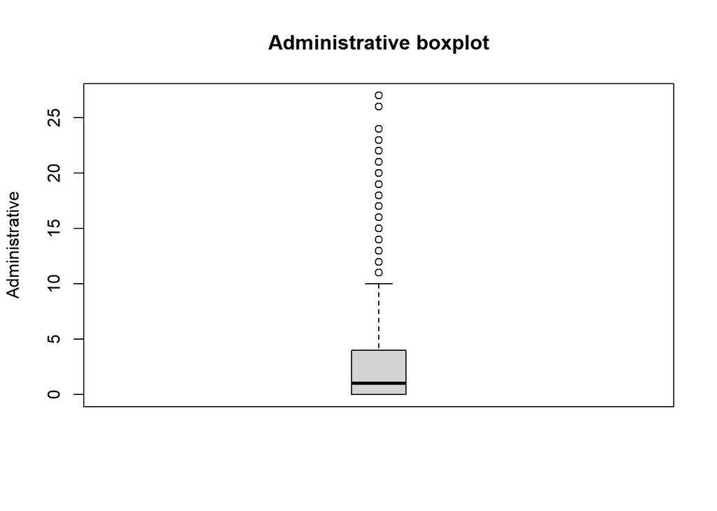

```r
#3.2bi. Checking the outliers in the 'Administrative' Column.
#
boxplot(cs_data$Administrative, main= "Administrative boxplot",ylab="Administrative", boxwex=0.2)
```

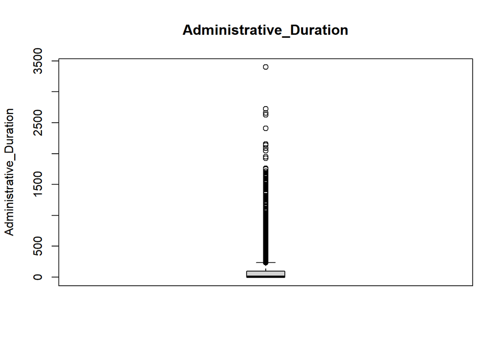

```r
#3.2bi. Checking the outliers in the 'Administrative_Duration' Column.
#
boxplot(cs_data$Administrative_Duration, main= "Administrative_Duration",ylab="Administrative_Duration", boxwex=0.2)
```

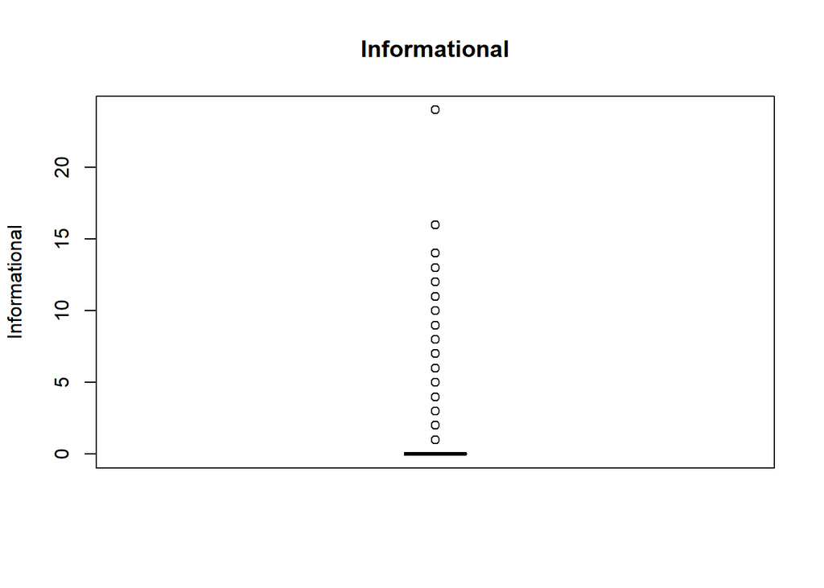

```r
#3.2bi. Checking the outliers in the 'Informational' Column.
#
boxplot(cs_data$Informational, main= "Informational",ylab="Informational", boxwex=0.2)
```

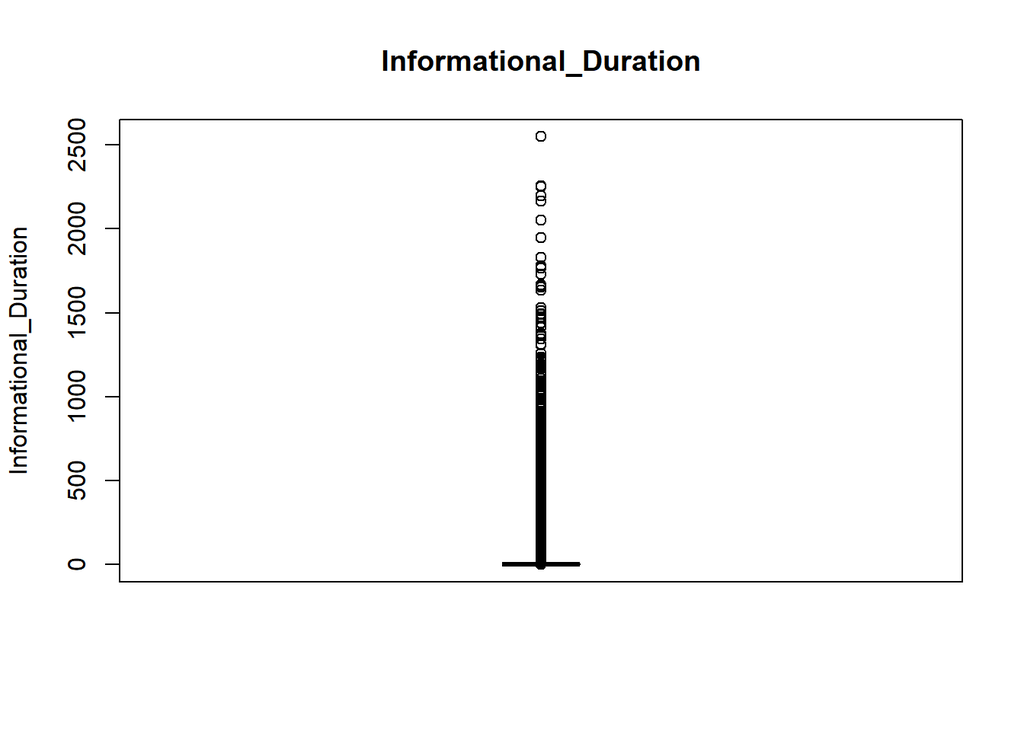

```r
#3.2bi. Checking the outliers in the 'Informational_Duration' Column.
#
boxplot(cs_data$Informational_Duration, main= "Informational_Duration",ylab="Informational_Duration", boxwex=0.2)
```

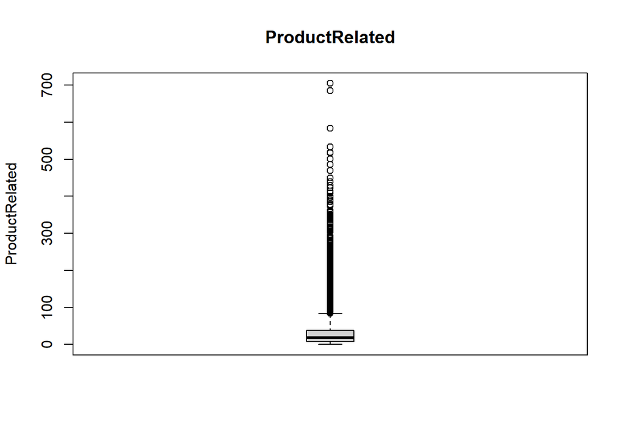

```r
#3.2bi. Checking the outliers in the 'ProductRelated' Column.
#
boxplot(cs_data$ProductRelated, main= "ProductRelated",ylab="ProductRelated", boxwex=0.2)
```

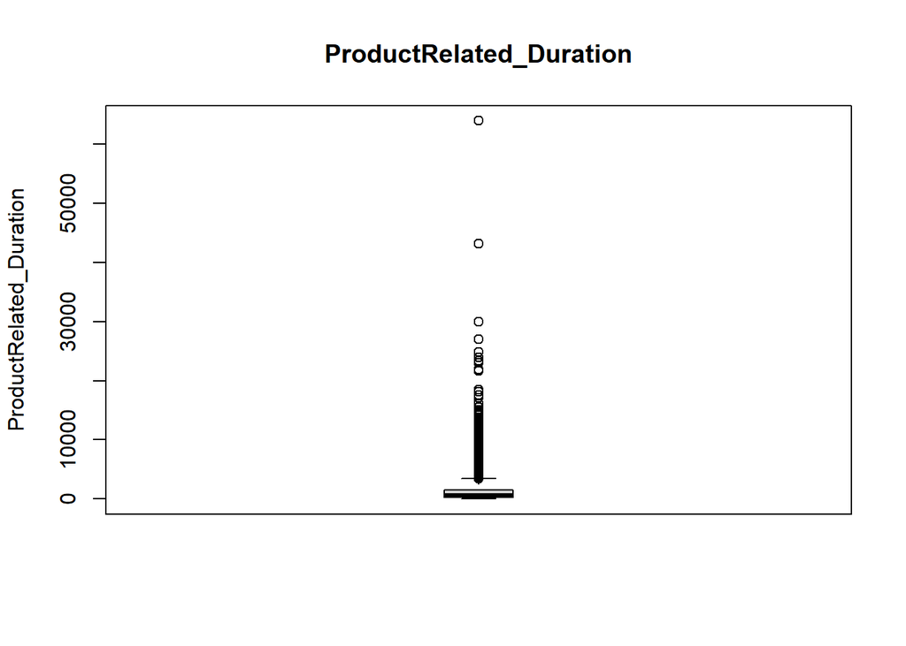

```r
#3.2bi. Checking the outliers in the 'ProductRelated_Duration' Column.
#
boxplot(cs_data$ProductRelated_Duration, main= "ProductRelated_Duration",ylab="ProductRelated_Duration", boxwex=0.2)
```

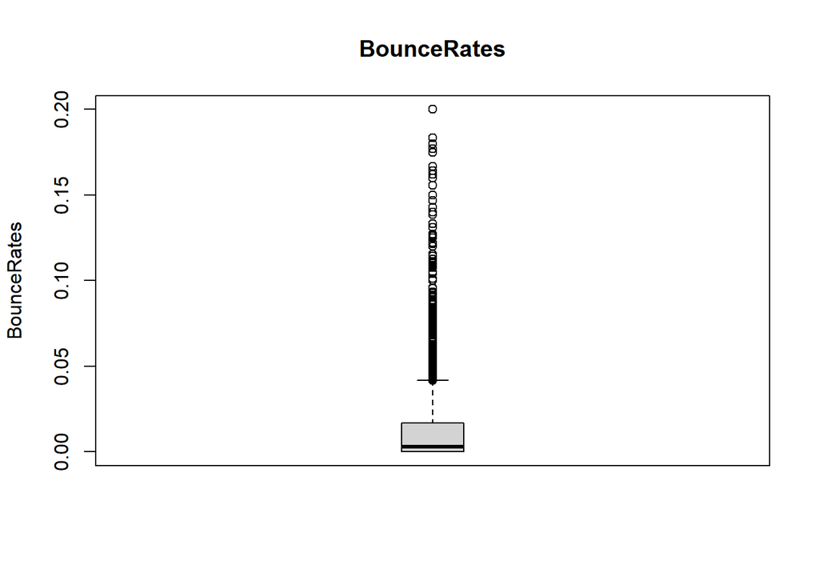

```r
#3.2bi. Checking the outliers in the 'BounceRates' Column.
#
boxplot(cs_data$BounceRates, main= "BounceRates",ylab="BounceRates", boxwex=0.2)
```

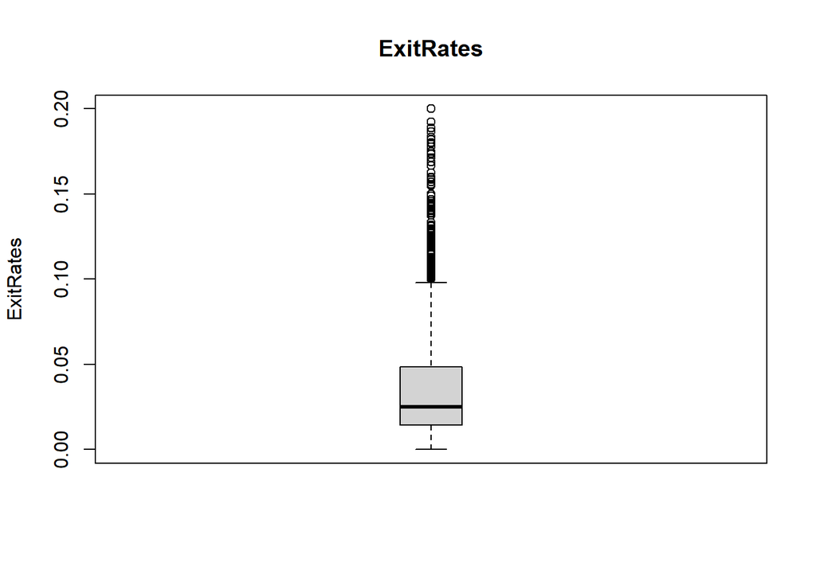

```r
#3.2bi. Checking the outliers in the 'ExitRates' Column.
#
boxplot(cs_data$ExitRates, main= "ExitRates",ylab="ExitRates", boxwex=0.2)
```

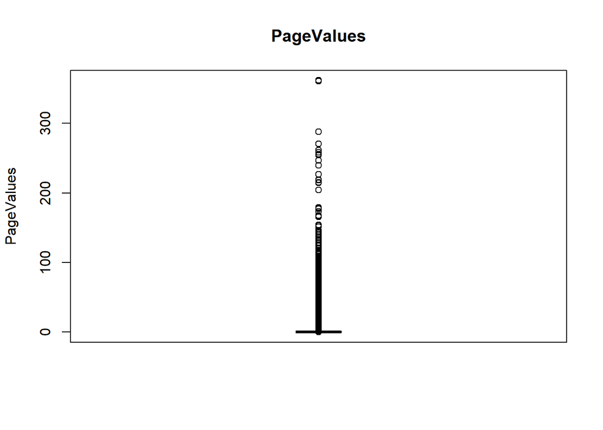

```r
#3.2bi. Checking the outliers in the 'PageValues' Column.
#
boxplot(cs_data$PageValues, main= "PageValues",ylab="PageValues", boxwex=0.2)
```

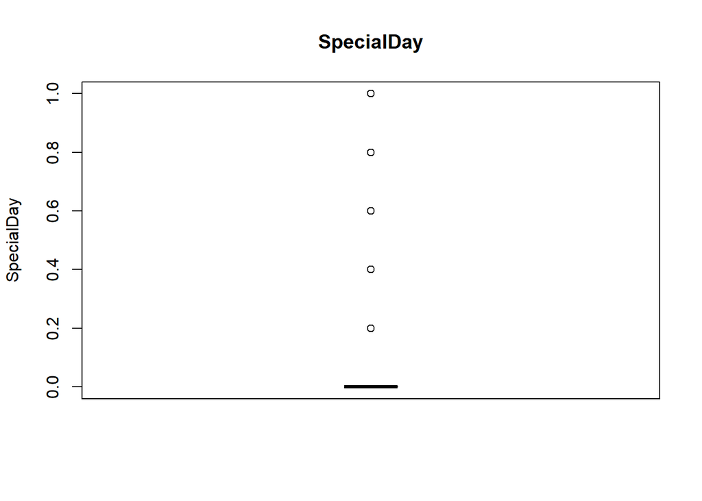

```r
#3.2bi. Checking the outliers in the 'SpecialDay' Column.
#
boxplot(cs_data$SpecialDay, main= "SpecialDay",ylab="SpecialDay", boxwex=0.2)
```

### previewing the numerical variables using histograms to check skewness.

```r
#3.3ai installing ggplot2 package for visualization.
#install.packages('ggplot2')
#
#installing ggplot2 library
#
library(ggplot2)
#
#note: the above  have been installed in the console section.
```

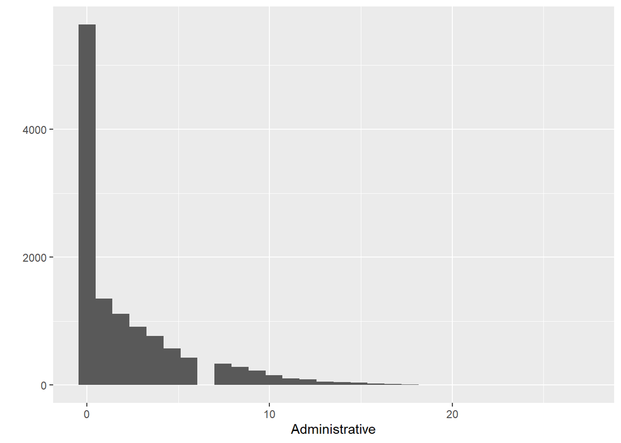

```r
#visualizing the Administrative column check for skewness
#
ggplot2::qplot(data = cs_data, x = Administrative)
```

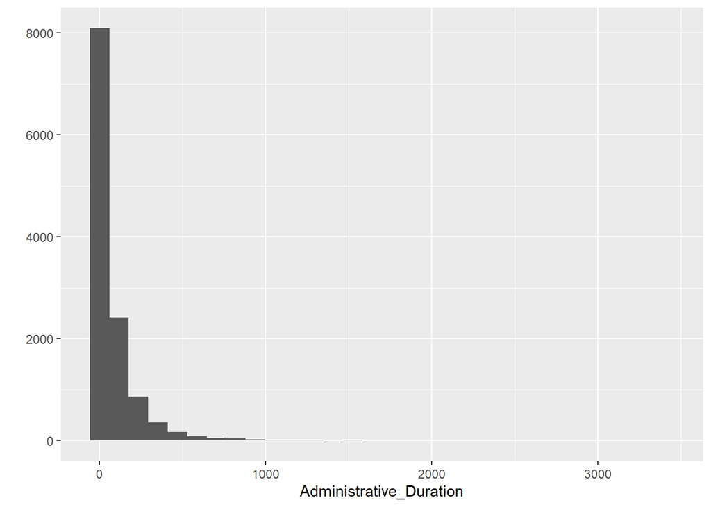

```r
#visualizing the Administrative_Duration column to check for skewness
#
ggplot2::qplot(data = cs_data, x = Administrative_Duration)
```

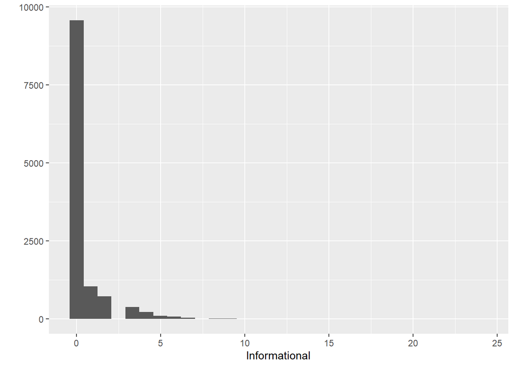

```r
#visualizing the Informational column to check for skewness
#
ggplot2::qplot(data = cs_data, x = Informational)
```

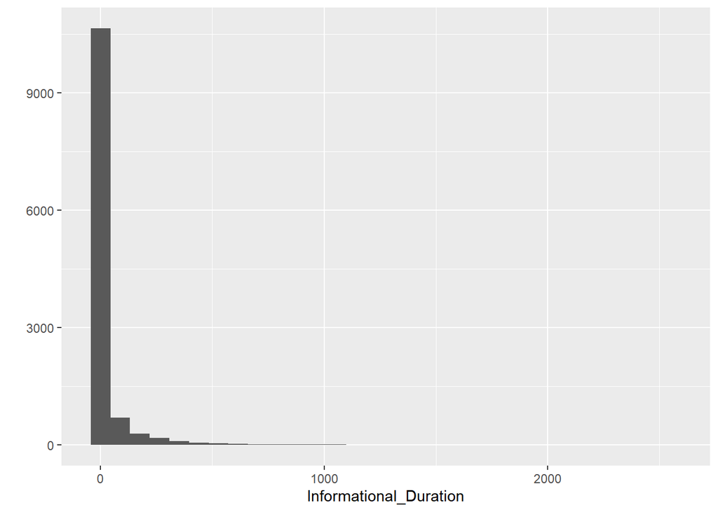

```r
#visualizing the Informational_Duration column to check for skewness
#
ggplot2::qplot(data = cs_data, x = Informational_Duration)
```

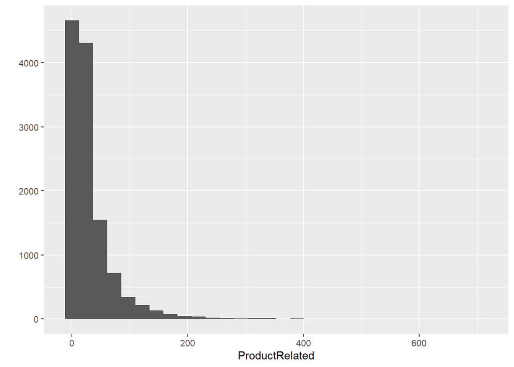

```r
#visualizing the  column to check for skewness
#
ggplot2::qplot(data = cs_data, x = ProductRelated)
```

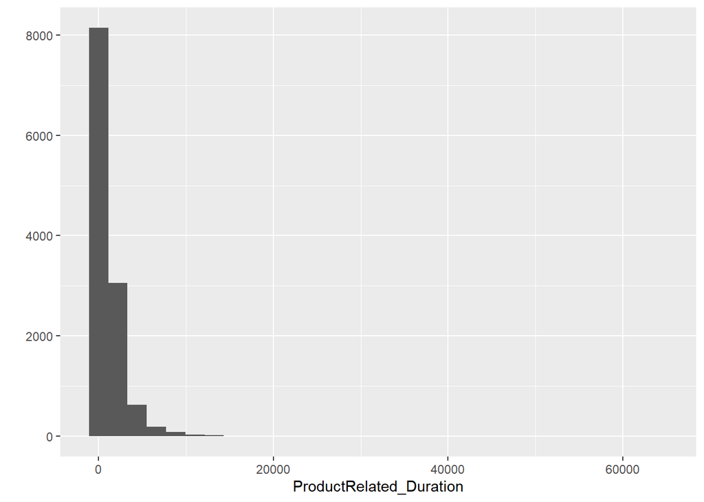

```r
#visualizing the  ProductRelated_Duration column to check for skewness
#
ggplot2::qplot(data = cs_data, x = ProductRelated_Duration)
```

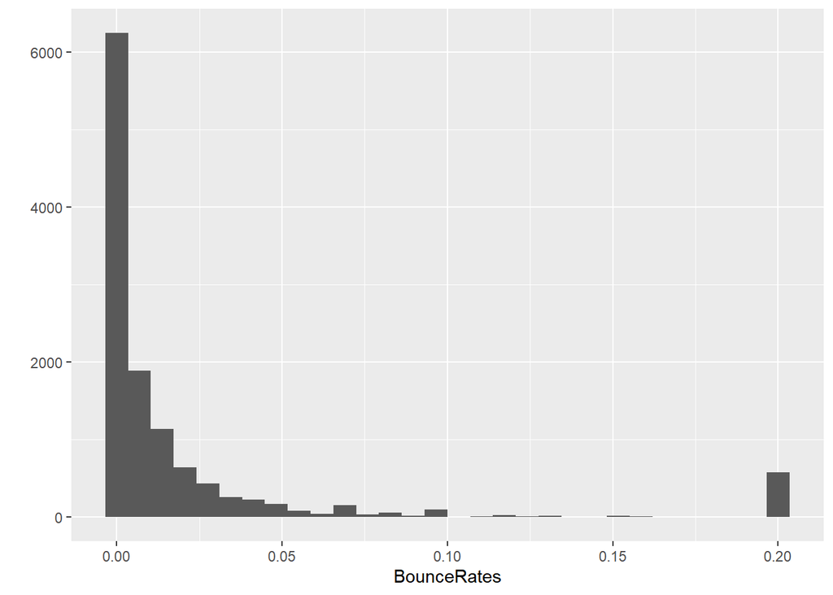

```r
#visualizing the BounceRates column to check for skewness
#
ggplot2::qplot(data = cs_data, x = BounceRates)
```

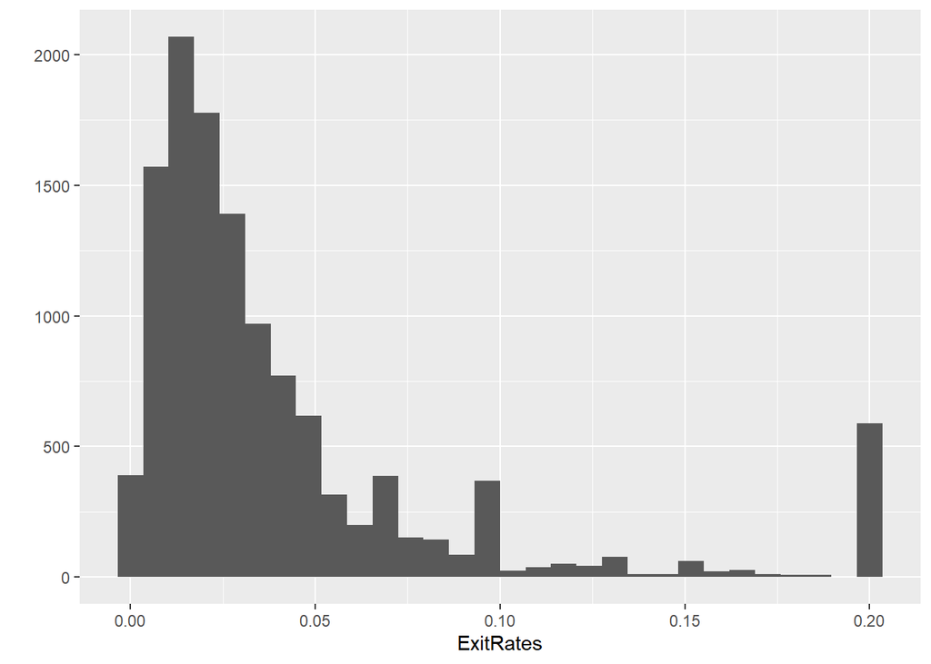

```r
#visualizing the ExitRates column to check for skewness
#
ggplot2::qplot(data = cs_data, x = ExitRates)
```

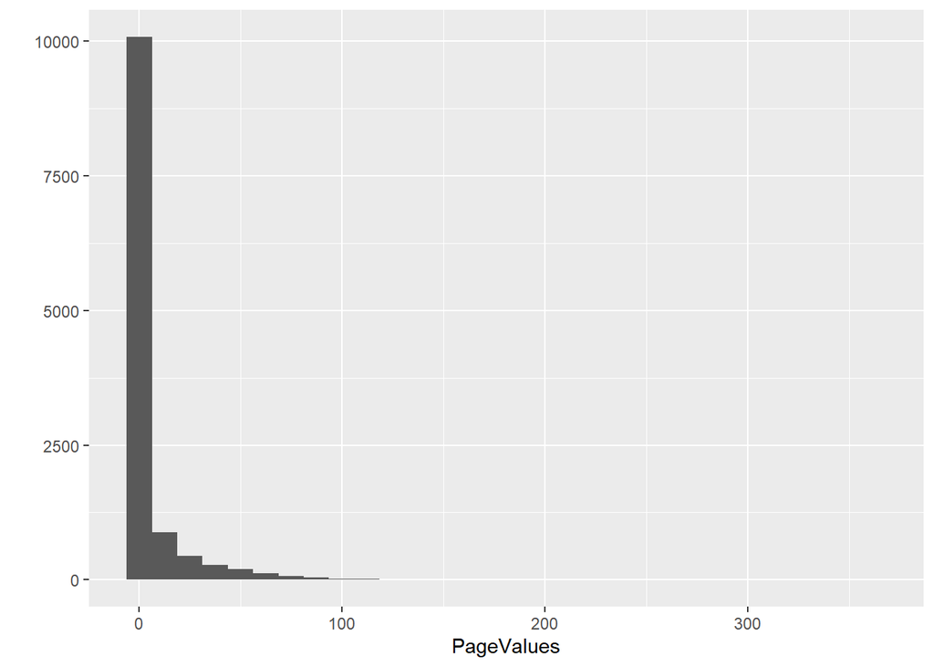

```r
#visualizing the PageValues colunm to check for skewness
#
ggplot2::qplot(data = cs_data, x = PageValues)
```

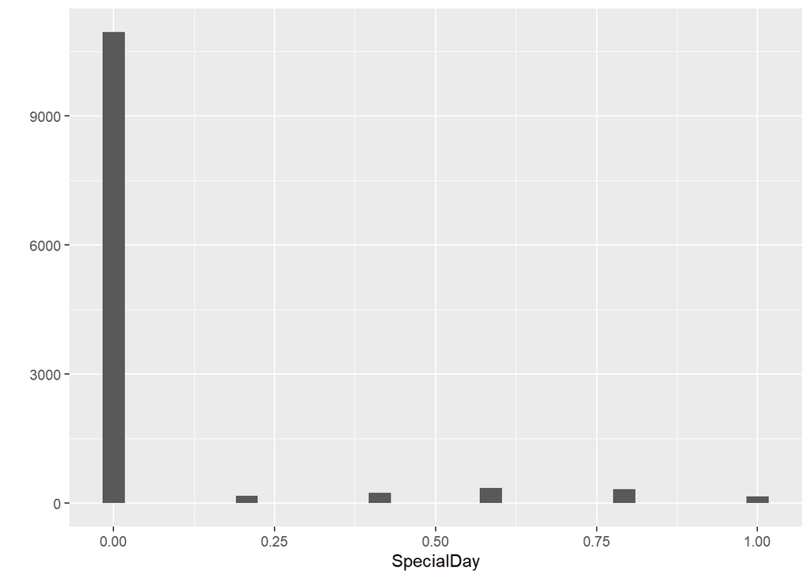

```r
#visualizing the SpecialDay  colunm to check for skewness
#
ggplot2::qplot(data = cs_data, x = SpecialDay)
```

observation: All our numerical variables have outliers are positively skewed.

```r
#importing library for visualization
#
library(dplyr)
library(tidyr)
library("ggplot2")
```

## we can check skewness for numerical values at once as below

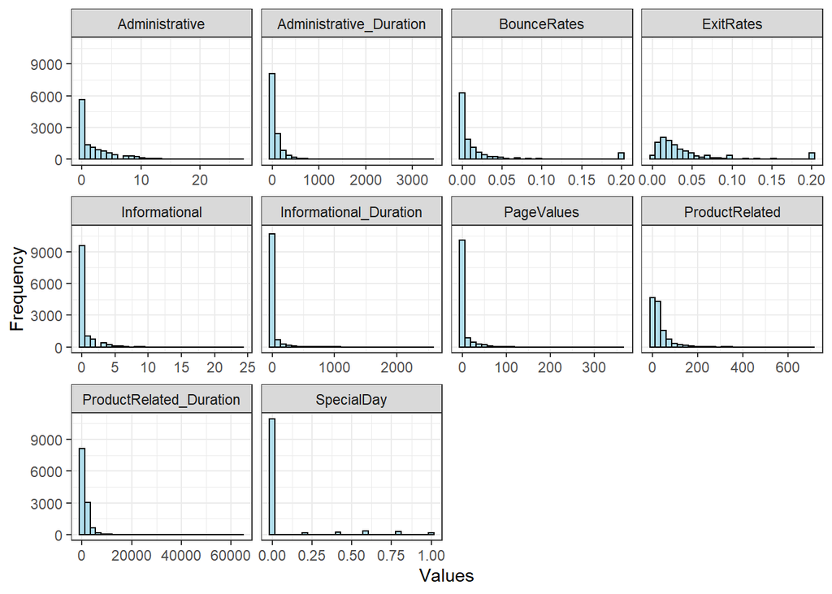

```r
cs_data%>%
  gather(attributes, value, 1:10) %>%
  ggplot(aes(x = value)) +
  geom_histogram(fill = 'lightblue2', color = 'black') +
  facet_wrap(~attributes, scales = 'free_x') +
  labs(x="Values", y="Frequency") +
  theme_bw()
```

observation: shows skewness to the right(positive skewness).

### 4.1b univariate Analysis for categorical Data

```r
## Identifying the categorical class in the data
#
#Checking the data types of the columns
#
cs_categorical<- cs_data %>% select_if(is.factor)
cs_categorical
```

```
## # A tibble: 12,199 x 8
##    Month OperatingSystems Browser Region TrafficType VisitorType Weekend Revenue
##    <fct> <fct>            <fct>   <fct>  <fct>       <fct>       <fct>   <fct>
##  1 Feb   1                1       1      1           Returning_~ FALSE   FALSE
##  2 Feb   2                2       1      2           Returning_~ FALSE   FALSE
##  3 Feb   4                1       9      3           Returning_~ FALSE   FALSE
##  4 Feb   3                2       2      4           Returning_~ FALSE   FALSE
##  5 Feb   3                3       1      4           Returning_~ TRUE    FALSE
##  6 Feb   2                2       1      3           Returning_~ FALSE   FALSE
##  7 Feb   2                4       3      3           Returning_~ FALSE   FALSE
##  8 Feb   1                2       1      5           Returning_~ TRUE    FALSE
##  9 Feb   2                2       2      3           Returning_~ FALSE   FALSE
## 10 Feb   2                4       1      2           Returning_~ FALSE   FALSE
## # ... with 12,189 more rows
```

## creating tables for bar plots.

```r
# create tables of all categorical variables to be able to create bar plots with them
month_table <- table(cs_data$Month)
os_table <- table(cs_data$OperatingSystems)
browser_table <- table(cs_data$Browser)
region_table <- table(cs_data$Region)
traffic_table <- table(cs_data$TrafficType)
visitor_table <- table(cs_data$VisitorType)
weekend_table <- table(cs_data$Weekend)
revenue_table <- table(cs_data$Revenue)
```

### adjusting plot size.

```r
# function for adjusting plot size
set_plot_dimensions <- function(width_choice, height_choice) {
    options(repr.plot.width = width_choice, repr.plot.height = height_choice)
}
```

```r
# barplot of Month
set_plot_dimensions(5, 4)
month_table
```

```
##
##  Aug  Dec  Feb  Jul June  Mar  May  Nov  Oct  Sep
##  433 1706  182  432  285 1853 3328 2983  549  448
```

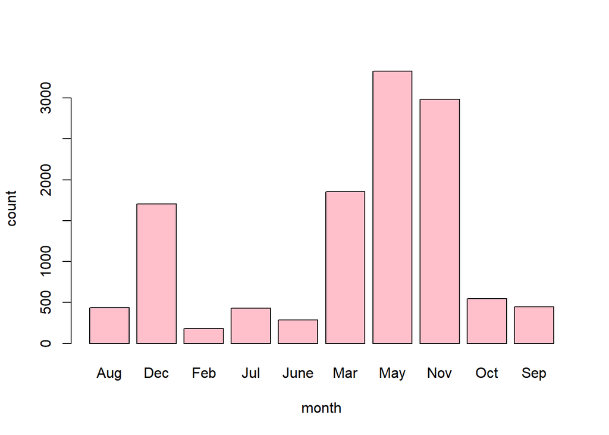

```r
barplot(month_table, ylab = "count", xlab="month", col="pink")
```

observation: May is the most frequently occurring month with February being the least frequently occurring.

```r
# barplot of operating system
set_plot_dimensions(5, 4)
os_table
```

```
##
##    1    2    3    4    5    6    7    8
## 2548 6536 2530  478    6   19    7   75
```

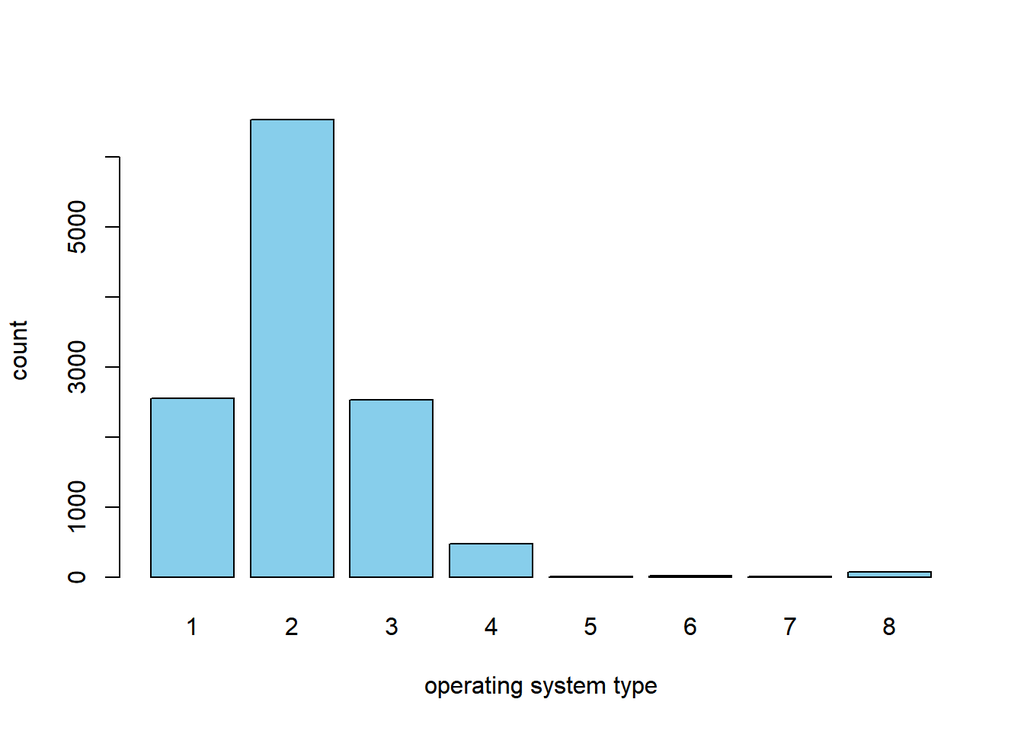

```r
barplot(os_table, ylab = "count", xlab="operating system type", col="sky blue")
```

observartion; Operating System 2 is the most widely used Operating System, followed by OS 1 and 3 which seem to be almost the same. OS 5 is the least used operating system.

```r
# barplot of browser
set_plot_dimensions(5, 4)
browser_table
```

```
##
##    1    2    3    4    5    6    7    8    9   10   11   12   13
## 2426 7878  105  730  466  174   49  135    1  163    6   10   56
```

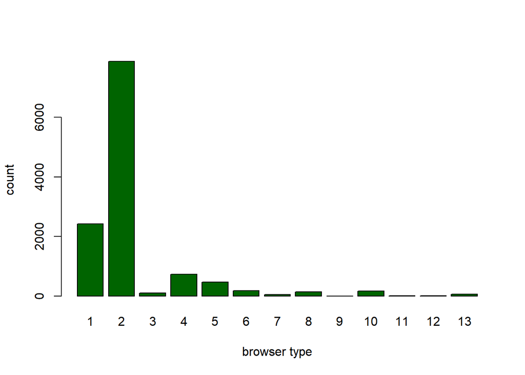

```r
barplot(browser_table, ylab = "count", xlab="browser type", col="dark green")
```

observation: Browser 2 is the most widely used browser and it’s followed by Browser 1. Browsers 9, 11, and 12 appear to be the least used browsers.

```r
# barplot of region
set_plot_dimensions(5, 4)
region_table
```

```
##
##    1    2    3    4    5    6    7    8    9
## 4711 1127 2382 1168  317  800  758  431  505
```

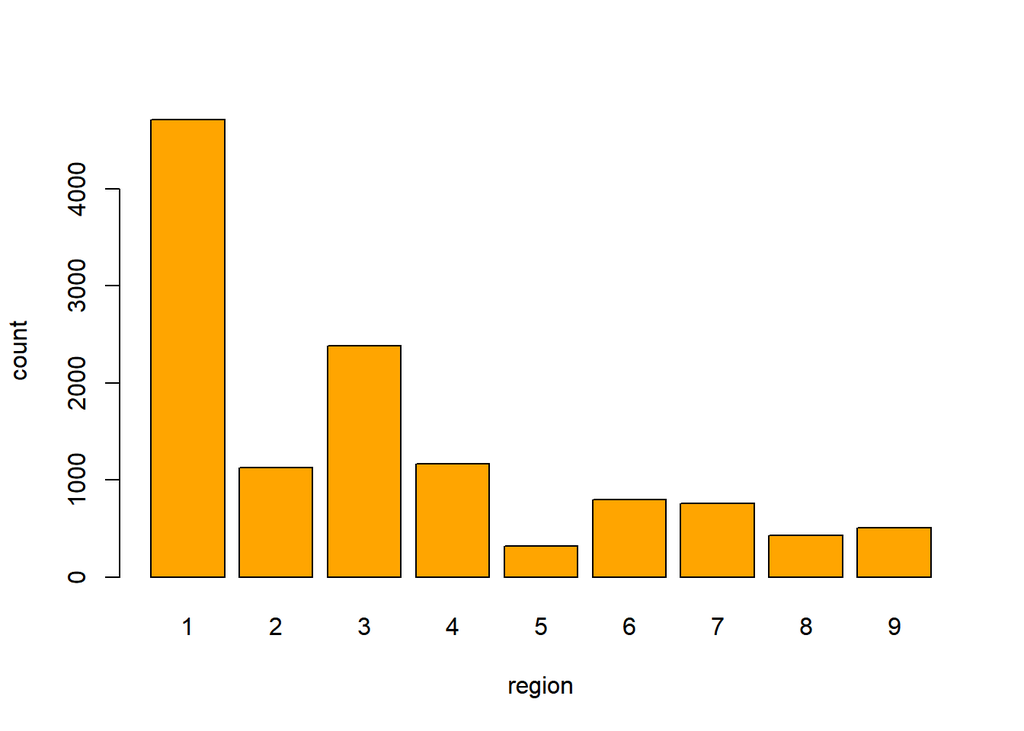

```r
barplot(region_table, ylab = "count", xlab="region", col="orange")
```

observation: Region 1 is the most occurring region while Region 5 is the least occurring.

```r
# barplot of traffic
set_plot_dimensions(5, 4)
traffic_table
```

```
##
##    1    2    3    4    5    6    7    8    9   10   11   12   13   14   15   16
## 2383 3907 2017 1066  260  443   40  343   41  450  247    1  728   13   36    3
##   17   18   19   20
##    1   10   17  193
```

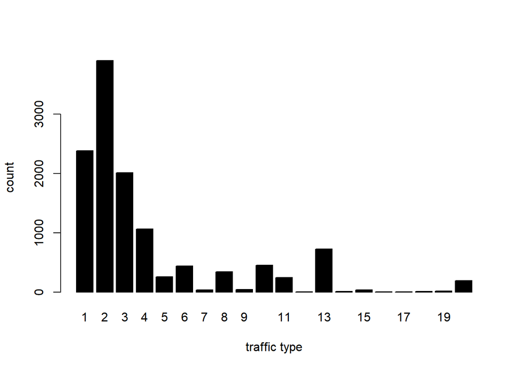

```r
barplot(traffic_table, ylab = "count", xlab="traffic type", col="black")
```

observation: Traffic Type 2 is the highest followed by Type 1 and Type 3. Type 12, 16, and 17 appear to be the least frequently occurring in the dataset.

```r
# barplot of visitor
set_plot_dimensions(5, 4)
visitor_table
```

```
##
##       New_Visitor             Other Returning_Visitor
##              1693                81             10425
```

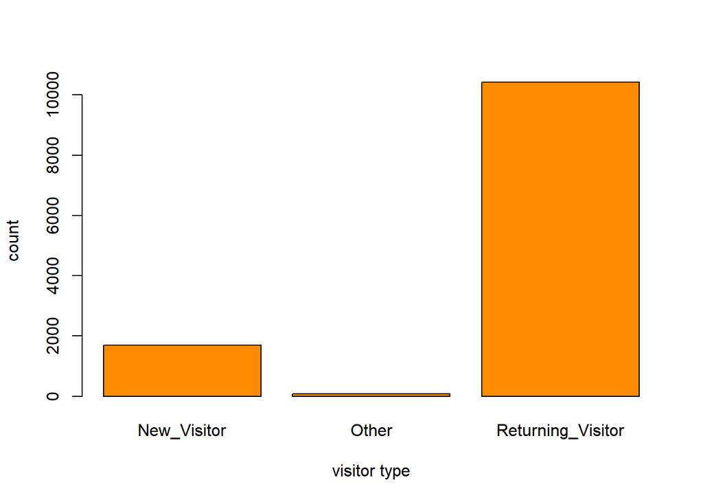

```r
barplot(visitor_table, ylab = "count", xlab="visitor type", col="dark orange")
```

observation: Majority of the visitors are returning; they are not new to this business.

```r
# barplot of weekend
set_plot_dimensions(5, 4)
weekend_table
```

```
##
## FALSE  TRUE
##  9343  2856
```

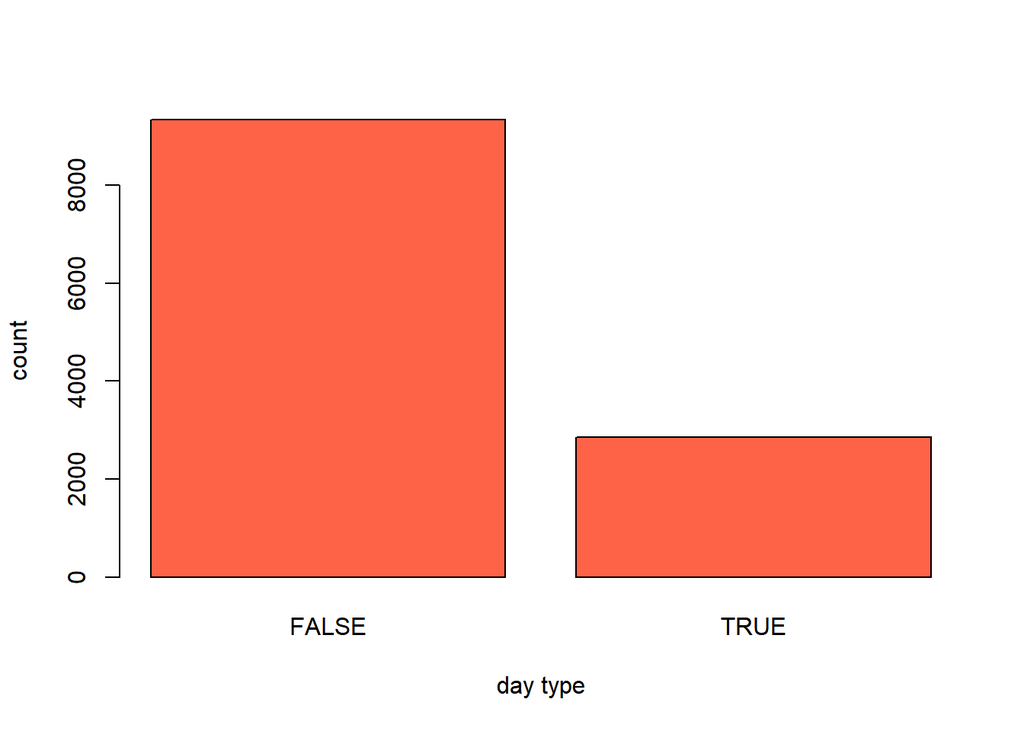

```r
barplot(weekend_table, ylab = "count", xlab="day type", col="tomato")
```

observation: Weekdays outnumber weekends in this dataset.

```r
# barplot of revenue
set_plot_dimensions(5, 4)
revenue_table
```

```
##
## FALSE  TRUE
## 10291  1908
```

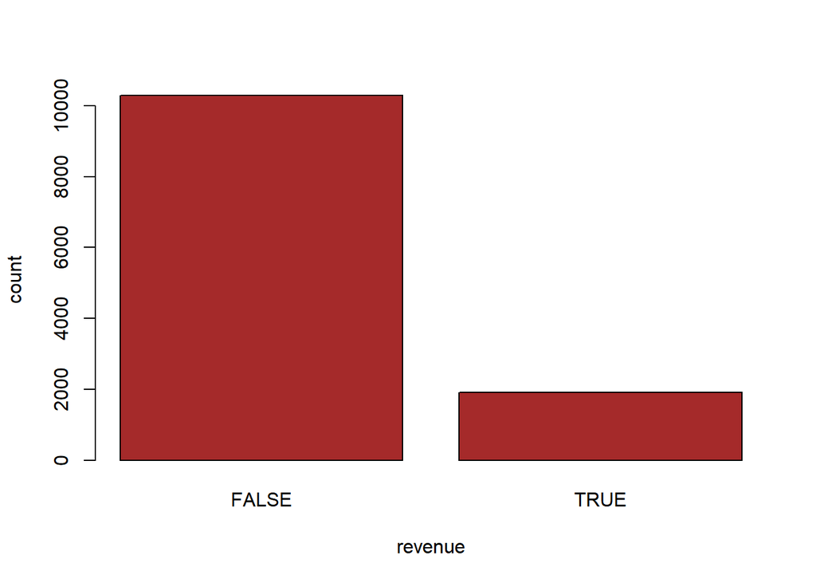

```r
barplot(revenue_table,ylab = "count", xlab="revenue", col="brown" )
```

observation: There are more FALSE revenues than true ones by a huge margin.